# Introduction to linear mixed models

timotheenivalis.github.io  
June 15 2018

### Example: hidden relationships

```r
thorns <- read.table(file = "thorndata.txt", header=TRUE)
```

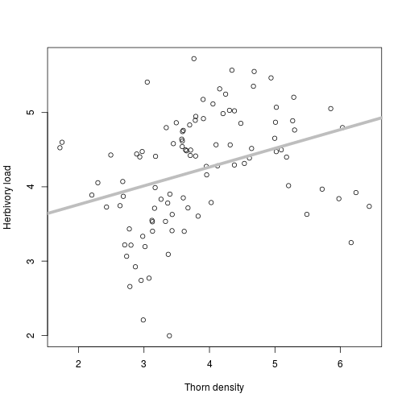

```r
plot(thorns$response, x=thorns$predictor, ylab = "Herbivory load", xlab= "Thorn density")
abline(lm(response~ predictor, data=thorns), lwd=5, col="gray")#this is a shortcut to draw a regression line
```

### Example: hidden relationships

```r
lmthorns <- lm(response~ predictor, data=thorns)
summary(lmthorns)
```

```
Call:
lm(formula = response ~ predictor, data = thorns)

Residuals:
     Min       1Q   Median       3Q      Max
-2.11617 -0.51831  0.08215  0.54349  1.51932

Coefficients:
            Estimate Std. Error t value Pr(>|t|)
(Intercept)   3.2564     0.2854   11.41  < 2e-16 ***
predictor     0.2524     0.0717    3.52 0.000657 ***
---
Signif. codes:  0 '***' 0.001 '**' 0.01 '*' 0.05 '.' 0.1 ' ' 1

Residual standard error: 0.7252 on 98 degrees of freedom
Multiple R-squared:  0.1122,    Adjusted R-squared:  0.1032
F-statistic: 12.39 on 1 and 98 DF,  p-value: 0.0006566
```

### Example: hidden relationships

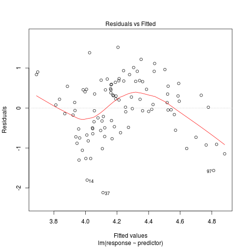

```r
plot(lmthorns, which=1)
```

### Example: hidden relationships

*Simpson's paradox*

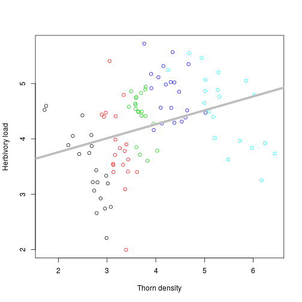

```r
plot(thorns$predictor, thorns$response, col=thorns$block, ylab = "Herbivory load", xlab= "Thorn density")
abline(lm(response~ predictor, data=thorns), lwd=5, col="gray")
```

### Example: hidden relationships

Fixed-effect correction

```r
summary(lm(response~ predictor + as.factor(block), data=thorns))
```

```
Call:
lm(formula = response ~ predictor + as.factor(block), data = thorns)

Residuals:
     Min       1Q   Median       3Q      Max
-1.68769 -0.28889  0.04982  0.24924  1.39683

Coefficients:
                  Estimate Std. Error t value Pr(>|t|)
(Intercept)         6.0471     0.3872  15.617  < 2e-16 ***
predictor          -0.9752     0.1414  -6.899 6.02e-10 ***
as.factor(block)2   0.9400     0.1762   5.334 6.62e-07 ***
as.factor(block)3   1.9958     0.2147   9.295 5.80e-15 ***
as.factor(block)4   2.9706     0.2812  10.562  < 2e-16 ***
as.factor(block)5   3.7674     0.4219   8.929 3.48e-14 ***
---
Signif. codes:  0 '***' 0.001 '**' 0.01 '*' 0.05 '.' 0.1 ' ' 1

Residual standard error: 0.4875 on 94 degrees of freedom
Multiple R-squared:  0.6151,    Adjusted R-squared:  0.5947
F-statistic: 30.05 on 5 and 94 DF,  p-value: < 2.2e-16
```

### Example: hidden relationships

```r
library(lme4)
thornLMM <- lmer(response ~ predictor + (1|block), data = thorns)
summary(thornLMM)
```

```
Linear mixed model fit by REML ['lmerMod']
Formula: response ~ predictor + (1 | block)
   Data: thorns

REML criterion at convergence: 165.3

Scaled residuals:
    Min      1Q  Median      3Q     Max
-3.4884 -0.6059  0.1091  0.5234  2.8735

Random effects:
 Groups   Name        Variance Std.Dev.
 block    (Intercept) 2.129    1.4590
 Residual             0.238    0.4878
Number of obs: 100, groups:  block, 5

Fixed effects:
            Estimate Std. Error t value
(Intercept)   7.7652     0.8441   9.199
predictor    -0.9189     0.1385  -6.633

Correlation of Fixed Effects:
          (Intr)
predictor -0.632
```

### Example: hidden relationships

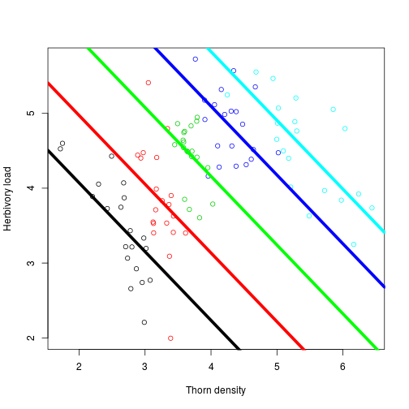

### Exercise: more hidden relationships

Load the data *thornsmanylocations.txt*

Compare **lm()** and **lmer()** corrections for block.

## What are random effects?

### Residuals and random effects

Assumed variance-covariance matrix of the process that generates the residuals

|  | obs1 | obs2 | obs3 | obs4 | obs5 |
| --- | --- | --- | --- | --- | --- |
| obs1 | 1 | 0 | 0 | 0 | 0 |
| obs2 | 0 | 1 | 0 | 0 | 0 |
| obs3 | 0 | 0 | 1 | 0 | 0 |
| obs4 | 0 | 0 | 0 | 1 | 0 |
| obs5 | 0 | 0 | 0 | 0 | 1 |

*residuals are perfectly correlated with themselves, and independent of each-other*

### Residuals and random effects

If multiple measurements:

|  |  | obs1 | obs2 | obs3 | obs4 | obs5 |
| --- | --- | --- | --- | --- | --- | --- |
|  |  | ind1 | ind1 | ind2 | ind2 | ind3 |
| obs1 | ind1 | 1 | 1 | 0 | 0 | 0 |
| obs2 | ind1 | 1 | 1 | 0 | 0 | 0 |
| obs3 | ind2 | 0 | 0 | 1 | 1 | 0 |
| obs4 | ind2 | 0 | 0 | 1 | 1 | 0 |
| obs5 | ind3 | 0 | 0 | 0 | 0 | 1 |

### Residuals and random effects

**Individual var-cov**

|  | ind1 | ind2 | ind3 |
| --- | --- | --- | --- |
| ind1 | 1 | 0 | 0 |
| ind2 | 0 | 1 | 0 |
| ind3 | 0 | 0 | 1 |

**Residual var-cov**

|  | obs1 | obs2 | obs3 | obs4 | obs5 |
| --- | --- | --- | --- | --- | --- |
| obs1 | 1 | 0 | 0 | 0 | 0 |
| obs2 | 0 | 1 | 0 | 0 | 0 |
| obs3 | 0 | 0 | 1 | 0 | 0 |
| obs4 | 0 | 0 | 0 | 1 | 0 |
| obs5 | 0 | 0 | 0 | 0 | 1 |

### NB: phylogenies, spatial correlation, time-series, genetic similarity...

…are mixed models with correlations across random effect levels (individuals, species, locations…)

|  |  | obs1 | obs2 | obs3 | obs4 | obs5 |
| --- | --- | --- | --- | --- | --- | --- |
|  |  | ind1 | ind1 | ind2 | ind3 | ind4 |
| obs1 | ind1 | 1 | 1 | 0.25 | 0 | 0.01 |
| obs2 | ind1 | 1 | 1 | 0 | 0 | 0 |
| obs3 | ind2 | 0.25 | 0 | 1 | 0 | 0 |
| obs4 | ind3 | 0 | 0 | 0 | 1 | 0.125 |
| obs5 | ind4 | 0.01 | 0 | 0 | 0.125 | 1 |

Correlations represent **(co-)variation that is unexplained**, but is **related to a biological process**

### Residuals and random effects

\[ y_{ij} = \mu + \beta x_{ij} + u_i + \epsilon_{ij} \] with, residuals \( \epsilon_{ij}\sim Normal(0,V_R) \) and individual random effect \( u_{i}\sim Normal(0,V_I) \).

Random effects are cool because:

- More efficient than estimating many independent fixed effects
- Avoid distration from many coefficients and p-values
- Test effect of grouping variable as one parameter
- Variance components biologically interesting (e.g. repeatability \( V_I/(V_I+V_R) \))

## Testing random effects significance

### Likelihood Ratio Test (LRT)

Comparison of two nested models. Ratio of likelihood \( \sim \chi^2 \)

```r
thornLMM <- lmer(response ~ predictor + (1|block), data = thorns)
thornLM <- lm(response ~ predictor, data = thorns)
anova(thornLMM, thornLM) # the mixed model MUST GO FIRST
```

```
Data: thorns
Models:
thornLM: response ~ predictor
thornLMM: response ~ predictor + (1 | block)
         Df    AIC    BIC   logLik deviance  Chisq Chi Df Pr(>Chisq)
thornLM   3 223.50 231.31 -108.749   217.50
thornLMM  4 172.05 182.47  -82.027   164.05 53.445      1   2.66e-13 ***
---
Signif. codes:  0 '***' 0.001 '**' 0.01 '*' 0.05 '.' 0.1 ' ' 1
```

### Exercise: LRT p-value distribution

One simulation with a random effect that has no effect

```r
set.seed(1234)
RandomVariance <- 0
sampsize <- 200
x <- rnorm(sampsize,mean = 4, sd=0.25)
nbblocks <- 50
block <- sample(x = 1:nbblocks, size = sampsize, replace = TRUE)
blockvalues <- rnorm(n = nbblocks, mean = 0, sd = sqrt(RandomVariance))
y <- 8 - x + blockvalues[block] + rnorm(sampsize,0,1)
dat <- data.frame(response = y, predictor = x, block=block)
```

```r
lm0 <- lm(response ~ 1 + predictor, data=dat)
lmm0 <- lmer(response ~ 1 + predictor + (1|block), data=dat )
(LRT0 <- anova(lmm0, lm0)) #mixed model must come first!
LRT0$`Pr(>Chisq)`[2] # the p-value
```

### Exercise: LRT p-value distribution

**Replicate the simulations to obtain the distribution of p-values under the null-model of no variance**

### Correct p-values in LRT

A variance cannot be negative

```r
confint(lmm0) #Confidence interval
```

LRT are two sided tests / count one parameter per random effect A random effect is half a parameter / to be tested with one-side tests

**Divide the p-values by two**

Same problem with AIC/BIC: count only half a parameter per random effect **Remove one IC point per random effect**

*NB: it is more complicated with random interactions; but the rule is to count half a parameter by variance parameter*

### Test / remove non-significant random effects?

**Test ?**

- Yes if effect of interest
- Maybe if only a nuisance parameter

**Remove ?**

- Probably should keep if part of exp. design
- Doesn't matter much if non-significant
- Maybe remove if too many variables in exploratory analyses

## Beyond the random intercept

### Random interactions, random slopes...

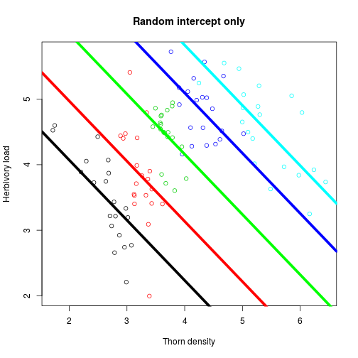

### Random interactions, random slopes...

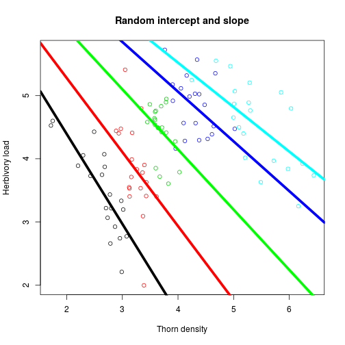

### Random interactions, random slopes...

“Random interaction” predictor:block = “random slope” = “random regression”

```r
lmer(response ~ 1 + predictor + (1+predictor|block), data=thorns)
```

Blocks allowed to differ in intercept and slopes

Fits 2 variances and 1 covariance

Syntax to more random effects: http://bbolker.github.io/mixedmodels-misc/glmmFAQ.html#model-specification

## Package demonstration

### Data

Load data to experiment with various packages

```r
dat <- read.table(file = "datforpackagecomp.txt", header=TRUE)
```

The simulated intercept variance among individual is 0.6. The simulated slope variance among individual is 0.01. The simulated effect of the predictor on the response is 0.2

### lme4

Standard, fast, simple package

```r
library(lme4)
```

```r
mlme4 <- lmer(response ~ 1 + predictor + (1|individual), data=dat)
summary(mlme4)
```

```
Linear mixed model fit by REML ['lmerMod']
Formula: response ~ 1 + predictor + (1 | individual)
   Data: dat

REML criterion at convergence: 5164.6

Scaled residuals:
    Min      1Q  Median      3Q     Max
-2.8690 -0.6772  0.0137  0.6656  3.0706

Random effects:
 Groups     Name        Variance Std.Dev.
 individual (Intercept) 0.5576   0.7467
 Residual               3.9580   1.9895
Number of obs: 1200, groups:  individual, 120

Fixed effects:
            Estimate Std. Error t value
(Intercept) 25.05978    0.09024 277.710
predictor    0.18881    0.06030   3.131

Correlation of Fixed Effects:
          (Intr)
predictor -0.010
```

### lme4

No p-values (for good reason) if you really want them:

```r
library(lmerTest)
summary(lmerTest::lmer(response ~ 1 + predictor + (1|individual), data=dat))
```

```
Linear mixed model fit by REML. t-tests use Satterthwaite's method [
lmerModLmerTest]
Formula: response ~ 1 + predictor + (1 | individual)
   Data: dat

REML criterion at convergence: 5164.6

Scaled residuals:
    Min      1Q  Median      3Q     Max
-2.8690 -0.6772  0.0137  0.6656  3.0706

Random effects:
 Groups     Name        Variance Std.Dev.
 individual (Intercept) 0.5576   0.7467
 Residual               3.9580   1.9895
Number of obs: 1200, groups:  individual, 120

Fixed effects:
             Estimate Std. Error        df t value Pr(>|t|)
(Intercept) 2.506e+01  9.024e-02 1.172e+02 277.710  < 2e-16 ***
predictor   1.888e-01  6.030e-02 1.154e+03   3.131  0.00178 **
---
Signif. codes:  0 '***' 0.001 '**' 0.01 '*' 0.05 '.' 0.1 ' ' 1

Correlation of Fixed Effects:
          (Intr)
predictor -0.010
```

### lme4

Rudimentary diagnostic

```r
plot(mlme4)
```

S4, complicated components:

```r
mlme4@beta
mlme4@u
```

Better use functions to extract components:

```r
fixef(mlme4)
ranef(mlme4)
VarCorr(mlme4)
```

Individual repeatability:

```r
as.numeric(VarCorr(mlme4)$individual)/sum(getME(mlme4, "sigma")^2, as.numeric(VarCorr(mlme4)$individual))
```

```
[1] 0.1234766
```

### glmmTMB

In development, more options (e.g. Zero-Inflation) sometimes but a bit slower (lmm)/faster(glmm) than lme4, fewer diagnostic, less easy to extract coeff

```r
install.packages("glmmTMB")
```

```r
library(glmmTMB)
```

```r
mglmmtmb <- glmmTMB(response ~ 1 + predictor + (1|individual), data=dat)
summary(mglmmtmb)
```

```
 Family: gaussian  ( identity )
Formula:          response ~ 1 + predictor + (1 | individual)
Data: dat

     AIC      BIC   logLik deviance df.resid
  5165.8   5186.2  -2578.9   5157.8     1196

Random effects:

Conditional model:
 Groups     Name        Variance Std.Dev.
 individual (Intercept) 0.5495   0.7413
 Residual               3.9544   1.9886
Number of obs: 1200, groups:  individual, 120

Dispersion estimate for gaussian family (sigma^2): 3.95

Conditional model:
            Estimate Std. Error z value Pr(>|z|)
(Intercept) 25.05998    0.08990  278.75  < 2e-16 ***
predictor    0.18870    0.06029    3.13  0.00175 **
---
Signif. codes:  0 '***' 0.001 '**' 0.01 '*' 0.05 '.' 0.1 ' ' 1
```

### glmmTMB

No automated diagnostics:

```r
plot(mglmmtmb) #DOESN'T work yet
```

Estimate extraction from summary (other ways?)

Individual repeatability:

```r
smglmmtmb <- summary(mglmmtmb)

as.numeric(smglmmtmb$varcor$cond$individual)/(smglmmtmb$sigma^2 + as.numeric(smglmmtmb$varcor$cond$individual))
```

```
[1] 0.1220021
```

### MCMCglmm

Bayesian MCMC, slow compare to ML, more flexible, estimate better complicated problems, post-treatment very easy and statistically correct

```r
install.packages("MCMCglmm")
```

```r
library(MCMCglmm)
```

```r
mmcmcglmm <- MCMCglmm(fixed = response ~ 1 + predictor,
                      random =  ~individual, data=dat)
```

[output not shown]

```r
summary(mmcmcglmm)
```

```
 Iterations = 3001:12991
 Thinning interval  = 10
 Sample size  = 1000

 DIC: 5129.739

 G-structure:  ~individual

           post.mean l-95% CI u-95% CI eff.samp
individual    0.5632   0.3299   0.8262      881

 R-structure:  ~units

      post.mean l-95% CI u-95% CI eff.samp
units      3.97    3.652     4.32     1000

 Location effects: response ~ 1 + predictor

            post.mean l-95% CI u-95% CI eff.samp  pMCMC
(Intercept)  25.06243 24.88928 25.24056     1000 <0.001 ***
predictor     0.18690  0.07866  0.31341     1000 <0.001 ***
---
Signif. codes:  0 '***' 0.001 '**' 0.01 '*' 0.05 '.' 0.1 ' ' 1
```

### MCMCglmm

Diagnostics:

```r
plot(mmcmcglmm)
autocorr(mmcmcglmm$VCV)
summary(mmcmcglmm$VCV)
```

Repeatability

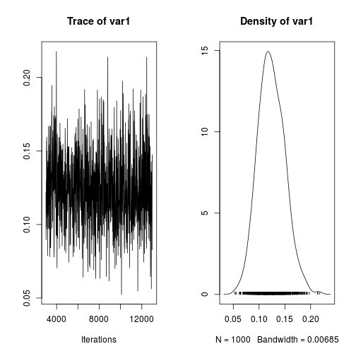

```r
mcmcmrep <- mmcmcglmm$VCV[,"individual"] / (mmcmcglmm$VCV[,"individual"] + mmcmcglmm$VCV[,"units"])
plot(mcmcmrep)
```

```r
posterior.mode(mcmcmrep)
```

```
     var1
0.1270167
```

```r
HPDinterval(mcmcmrep)
```

```
          lower     upper
var1 0.07613885 0.1753302
attr(,"Probability")
[1] 0.95
```

### brms

Bayesian Hamiltonian Monte Carlo based on STAN, very slow, but super efficient estimation, “infinitely” flexible (by modifying the STAN code)

```r
install.packages("brms")
install.packages("shinystan")
```

```r
library(brms)
library(shinystan)
```

```r
mbrms <- brm(formula = response ~ 1 + predictor + (1|individual), data=dat)
summary(mbrms)
```

Diagnostics:

```r
plot(mbrms)
launch_shinystan(mbrms)
```

### brms

```r
fixef(mbrms)
ranef(mbrms)
brms::VarCorr(mbrms)
```

Repeatability

```r
repbrms <- posterior_samples(mbrms, pars = "sd")^2 /(posterior_samples(mbrms, pars = "sd")^2 +posterior_samples(mbrms, pars = "sigma")^2)
plot(as.mcmc(repbrms))
```

### INLA

Bayesian Laplace Approximation, very fast, good estimation, not as flexible.

```r
install.packages("INLA", repos=c(getOption("repos"), INLA="https://inla.r-inla-download.org/R/stable"), dep=TRUE)
```

```r
library(INLA)
```

```r
minla <- inla(formula =response ~ 1 + predictor + f(individual, model = "iid"), data=dat )
summary(minla)
```

### Summary (based on personal exp.)

[output not shown]

| Package | Post_treatment | Whims | Structure |
| --- | --- | --- | --- |
| **lme4** | difficult | few | S4 |
| **glmmTMB** | difficult | some- | S3 |
| **MCMCglmm** | easy but manual | few | S3 |
| **brms** | easy(?) and automated | some | S3 |
| **INLA** | medium and manual | some+ | S3 |

### Exercise: Fit random regressions with the packages you like

### Exercise: Compare the speed of the different packages

And let me know what you find!

Hint:

```r
system.time()
```

### Essential resources

Ben Bolker FAQ: http://bbolker.github.io/mixedmodels-misc/glmmFAQ.html http://glmm.wikidot.com/start

Subscribe to mailing-list: https://stat.ethz.ch/mailman/listinfo/r-sig-mixed-models

MCMCglmm: https://cran.r-project.org/web/packages/MCMCglmm/vignettes/CourseNotes.pdf

brms: https://paul-buerkner.github.io/blog/brms-blogposts/ http://elevanth.org/blog/2017/11/28/build-a-better-markov-chain/